# Practical machine Learning

Paul Askew

28 March 2016

Practical Machine Learning Project

```r
#environment set up
setwd("C:/Users/Paul/OneDrive/Coursera/practicalmachinelearning")
set.seed(4059)
library(caret)
library(randomForest)
modelset<-read.csv("pml_train.csv",na.strings = c("NA", "","#DIV/0!"))
unneccols <- c("X", "user_name", "raw_timestamp_part_1", "raw_timestamp_part_2", "cvtd_timestamp", "new_window", "num_window")
NAs <- apply(modelset, 2, function(x){sum(is.na(x))})
modelset<-modelset[,which(NAs==0)]
modelset <- modelset[, -which(names(modelset) %in% unneccols)]
inTrain<-createDataPartition(y=modelset$classe,p=0.75, list=FALSE)
trainset<-modelset[inTrain,]
testset<-modelset[-inTrain,]
```

More information is available from the website here: http://groupware.les.inf.puc-rio.br/har (see the section on the Weight Lifting Exercise Dataset).

We have split the training data into a training set and a test set. Columns with NA have been removed reducing the number of variables form 160 to 60 which is much easier to handle. We have reduced the number of variables even further by removing some obvious parameters such as user_name. In earier tests when leaving these in the final test was incorrect showing the need to remove obviously unnecessary parameters. When testing this some of the models took a long time to train so the training and test set were comprised of 75% of the overall set. We will make the first model using the caret package to train with the rpart package. As we have reduced the number of variables this is done against the remaining variables

```
## CART
##
## 14718 samples
##    52 predictor
##     5 classes: 'A', 'B', 'C', 'D', 'E'
##
## No pre-processing
## Resampling: Bootstrapped (25 reps)
## Summary of sample sizes: 14718, 14718, 14718, 14718, 14718, 14718, ...
## Resampling results across tuning parameters:
##
##   cp          Accuracy   Kappa       Accuracy SD  Kappa SD
##   0.03322890  0.5116188  0.36501954  0.06078797   0.09984790
##   0.05984367  0.3980288  0.17785623  0.05513696   0.09235978
##   0.11535175  0.3273472  0.06531766  0.04284499   0.06409295
##
## Accuracy was used to select the optimal model using  the largest value.
## The final value used for the model was cp = 0.0332289.
```

We test the model, using the model with the predict function and each of the test sets and training sets. We see that it produces misclassfications.

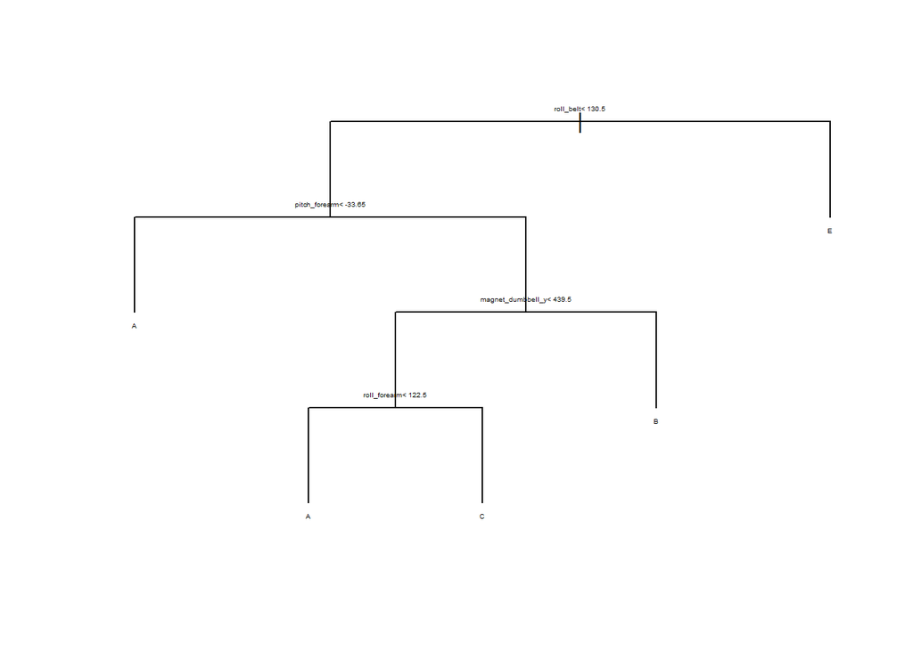

```r
predicttrain<-predict(fitmodel,trainset)
predicttest<-predict(fitmodel,testset)
missClass = function(values,prediction){round(sum(prediction!=values)/length(values)*100,2)}
plot(fitmodel$finalModel, uniform = T)
text(fitmodel$finalModel, cex=0.3)
```

The training set is misclassified 50.46% of the time and the test set is misclassifed 50.43% of the time. This is not good! Looking at the plot of the model we can see it is very poor and will never classify a D. Quite frankly this will take quite a bit of improving so we need to try something else, in this case a random forest. This was tried and took a long time to run so some preprocessing has been done to help reduce the run time. http://topepo.github.io/caret/training.html contains some useful background to the train function in caret.

```r
fitControl <- trainControl(method = "cv",number = 5)
newfit<-train(classe~.,data=trainset,preProcess=c("center", "scale"),method="rf",trcontrol=fitControl,prox=TRUE)
trainvalidate<-predict(newfit,trainset)
testvalidate<-predict(newfit,testset)
```

Looking at the misclassification this time the training set is misclassified 0% of the time and the test set is misclassified 0.67% of the time. This is effectively perfect for our purposes. Some plots of the random forest are given below.

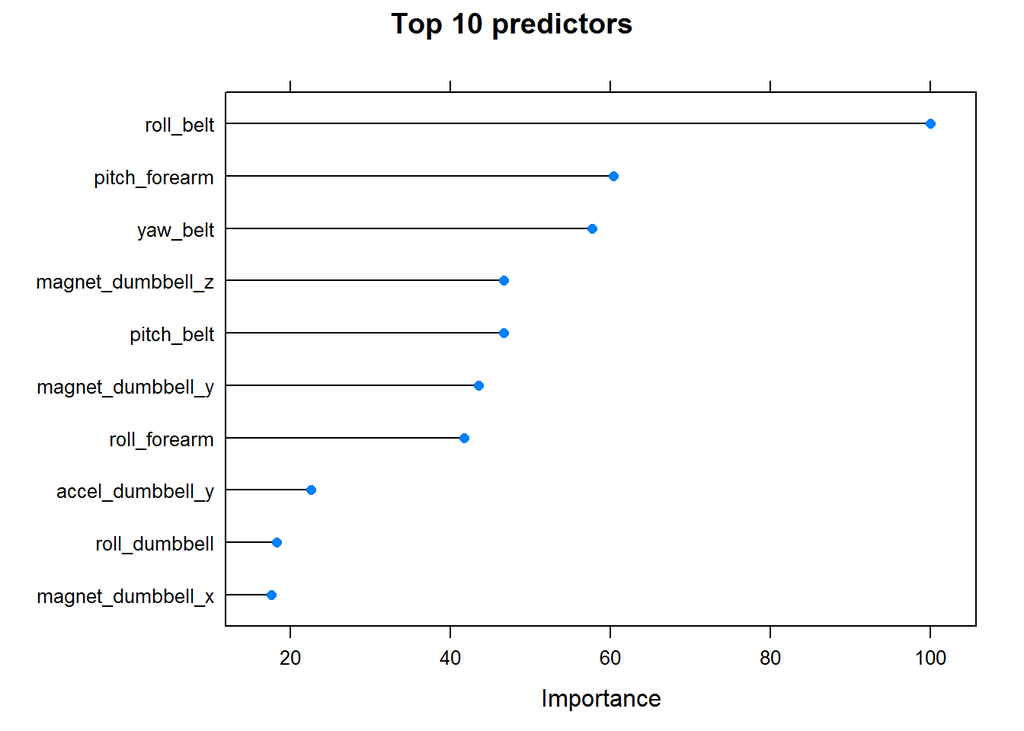

```r
plot(varImp(newfit), main = "Top 10 predictors", top = 10)
```

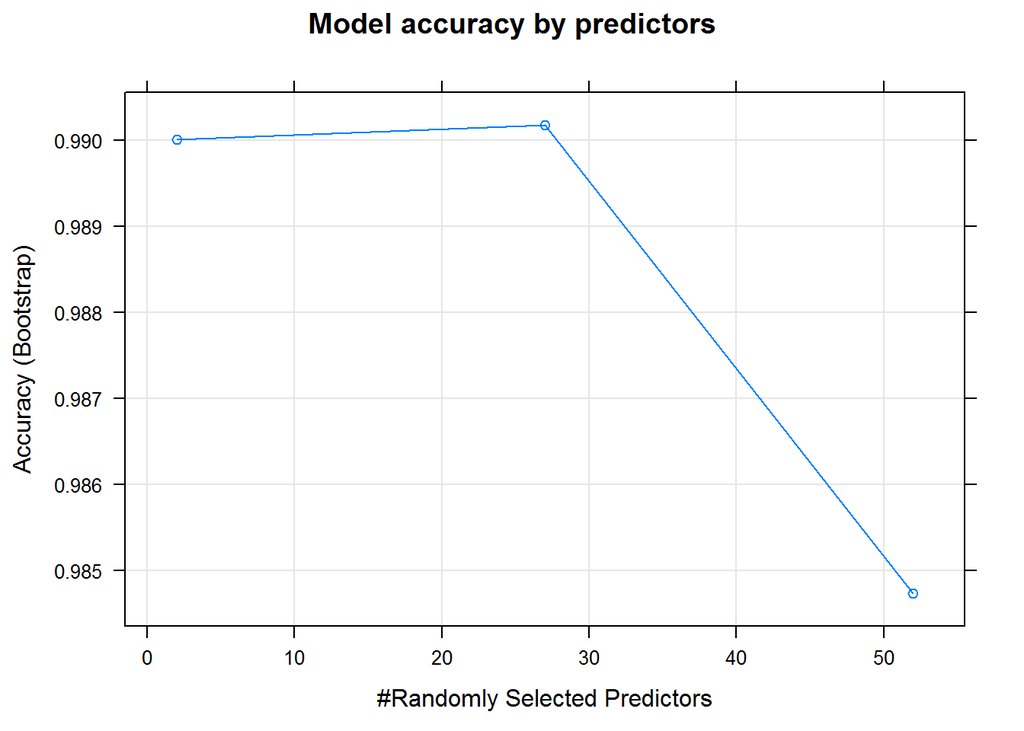

```r
plot(newfit, main="Model accuracy by predictors")
```

Finally just test the model against the test set provided for the project. Fortunately this gives us 100% in the quiz.

```r
quizset<-read.csv("pml_test.csv",na.strings = c("NA", "","#DIV/0!"))
NAs <- apply(quizset, 2, function(x){sum(is.na(x))})
quizset<-quizset[,which(NAs==0)]
quizset <- quizset[, -which(names(quizset) %in% unneccols)]
quizans<-predict(newfit,quizset)
#quizans
```

[output not shown]